# Student Performance Analysis Report

Hemant Borana

December 2025

## Introduction

This report analyzes student performance data to understand factors affecting academic achievement. The dataset contains information about 100 students including demographics, study habits, and test scores in Math, Reading, and Writing.

## Data Loading and Setup

```r
library(ggplot2)
library(dplyr)
library(readr)
library(tidyr)

student_data <- read.csv("Student_Performance.csv")
```

## Data Overview

```r
str(student_data)
```

```
## 'data.frame':    100 obs. of  10 variables:
##  $ StudentID                : int  1 2 3 4 5 6 7 8 9 10 ...
##  $ Age                      : int  17 17 17 16 17 16 16 16 17 15 ...
##  $ Gender                   : chr  "Male" "Female" "Female" "Male" ...
##  $ ParentalEducation        : chr  "Associate" "High School" "Master" "Associate" ...
##  $ StudyHours               : num  3.9 2.3 6.2 1.4 9.7 5.2 1.6 6.2 9.9 6.7 ...
##  $ Attendance               : num  65.9 74.3 86.9 81 74 69.6 62.3 69.5 95.6 92.5 ...
##  $ ExtracurricularActivities: chr  "No" "No" "Yes" "No" ...
##  $ MathScore                : int  49 74 91 73 86 46 64 83 78 48 ...
##  $ ReadingScore             : int  39 56 80 80 70 56 89 48 71 63 ...
##  $ WritingScore             : int  40 100 84 72 63 61 79 58 66 79 ...
```

```r
summary(student_data)
```

```
##    StudentID           Age           Gender          ParentalEducation
##  Min.   :  1.00   Min.   :15.00   Length:100         Length:100
##  1st Qu.: 25.75   1st Qu.:15.00   Class :character   Class :character
##  Median : 50.50   Median :16.00   Mode  :character   Mode  :character
##  Mean   : 50.50   Mean   :16.35
##  3rd Qu.: 75.25   3rd Qu.:17.00
##  Max.   :100.00   Max.   :18.00
##    StudyHours       Attendance    ExtracurricularActivities   MathScore
##  Min.   : 0.200   Min.   :60.00   Length:100                Min.   : 24.00
##  1st Qu.: 2.375   1st Qu.:69.42   Class :character          1st Qu.: 57.75
##  Median : 4.550   Median :77.85   Mode  :character          Median : 69.50
##  Mean   : 4.922   Mean   :79.14                             Mean   : 68.19
##  3rd Qu.: 7.375   3rd Qu.:89.95                             3rd Qu.: 79.00
##  Max.   :10.000   Max.   :99.70                             Max.   :100.00
##   ReadingScore    WritingScore
##  Min.   :38.00   Min.   : 40.00
##  1st Qu.:60.75   1st Qu.: 61.00
##  Median :70.50   Median : 72.00
##  Mean   :69.41   Mean   : 71.00
##  3rd Qu.:77.00   3rd Qu.: 80.25
##  Max.   :97.00   Max.   :100.00
```

The dataset contains 100 students with 10 variables including demographic information and academic scores.

## Data Manipulation

### Creating Summary Statistics

```r
gender_summary <- student_data %>%
  group_by(Gender) %>%
  summarise(
    Avg_Math = mean(MathScore),
    Avg_Reading = mean(ReadingScore),
    Avg_Writing = mean(WritingScore),
    Count = n()
  )
print(gender_summary)
```

```
## # A tibble: 2 × 5
##   Gender Avg_Math Avg_Reading Avg_Writing Count
##   <chr>     <dbl>       <dbl>       <dbl> <int>
## 1 Female     67.1        68.3        73.2    54
## 2 Male       69.5        70.7        68.4    46
```

**Interpretation:** The analysis shows differences in average scores between male and female students across subjects.

```r
parent_ed_summary <- student_data %>%
  group_by(ParentalEducation) %>%
  summarise(
    Avg_Math = mean(MathScore),
    Avg_Attendance = mean(Attendance),
    Total_Students = n()
  )
print(parent_ed_summary)
```

```
## # A tibble: 5 × 4
##   ParentalEducation Avg_Math Avg_Attendance Total_Students
##   <chr>                <dbl>          <dbl>          <int>
## 1 Associate             70.1           77.8             15
## 2 Bachelor              62.1           79.9             21
## 3 High School           68.8           78.4             25
## 4 Master                75.2           76.5             12
## 5 Some College          68.1           81.2             27
```

**Interpretation:** Students with parents holding Master’s degrees show higher average math scores, suggesting parental education may influence academic performance.

## Visualizations and Analysis

### 1. Gender Distribution

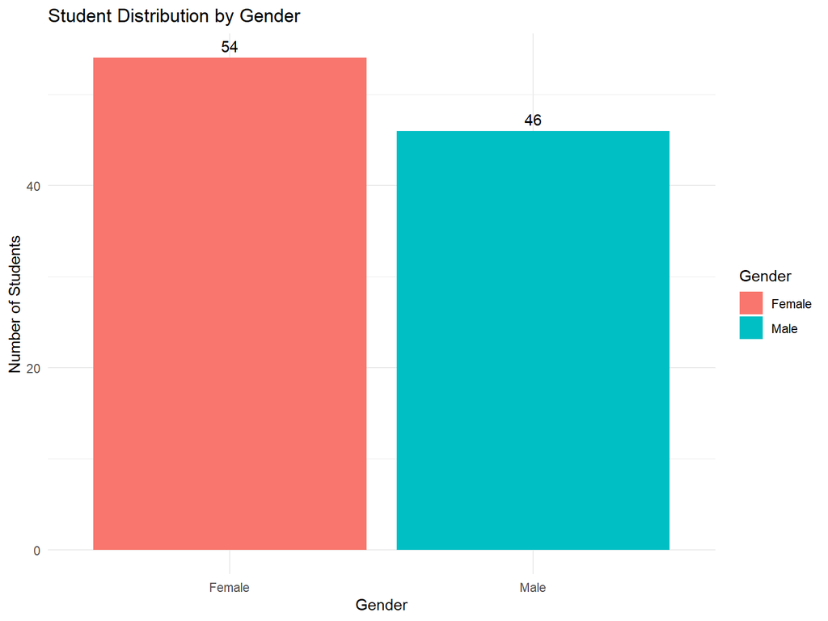

```r
ggplot(student_data, aes(x = Gender, fill = Gender)) +
  geom_bar() +
  labs(title = "Student Distribution by Gender",
       x = "Gender",
       y = "Number of Students") +
  theme_minimal() +
  geom_text(stat = 'count', aes(label = after_stat(count)), vjust = -0.5)
```

**Interpretation:** The dataset shows a relatively balanced gender distribution with slightly more female students (54) compared to male students (46).

### 2. Study Hours vs Math Score

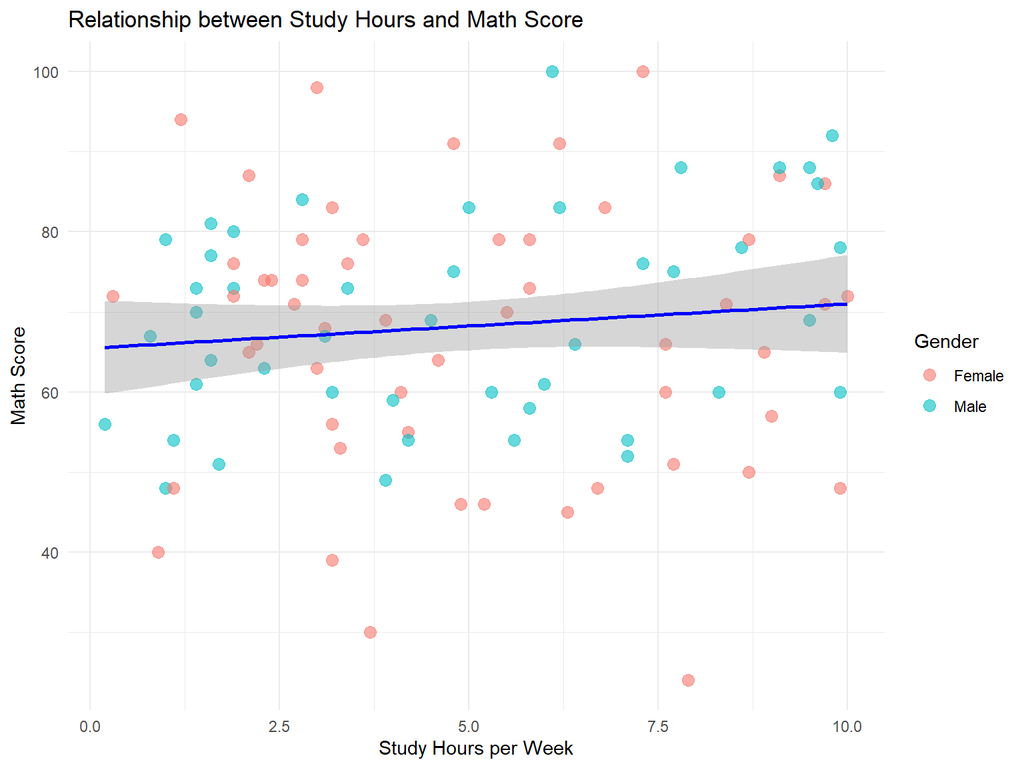

```r
ggplot(student_data, aes(x = StudyHours, y = MathScore)) +
  geom_point(aes(color = Gender), size = 3, alpha = 0.6) +
  geom_smooth(method = "lm", se = TRUE, color = "blue") +
  labs(title = "Relationship between Study Hours and Math Score",
       x = "Study Hours per Week",
       y = "Math Score") +
  theme_minimal()
```

### 3. Math Score Distribution

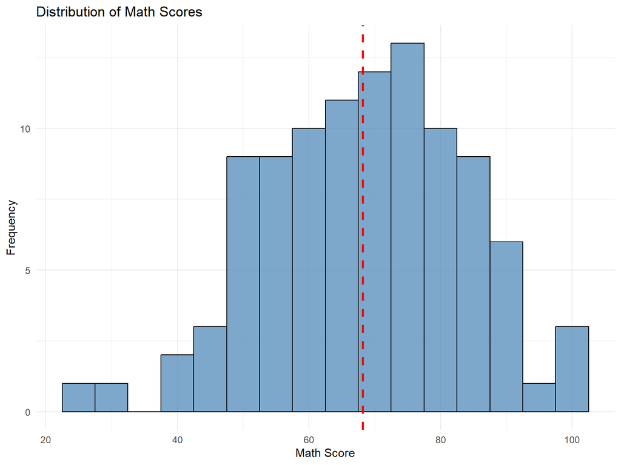

```r
ggplot(student_data, aes(x = MathScore)) +
  geom_histogram(binwidth = 5, fill = "steelblue", color = "black", alpha = 0.7) +
  labs(title = "Distribution of Math Scores",
       x = "Math Score",
       y = "Frequency") +
  theme_minimal() +
  geom_vline(aes(xintercept = mean(MathScore)),
             color = "red", linetype = "dashed", size = 1)
```

**Interpretation:** Math scores follow an approximately normal distribution with a mean around 68. Most students score between 55 and 80, with few students at the extreme low or high ends.

### 4. Scores by Parental Education

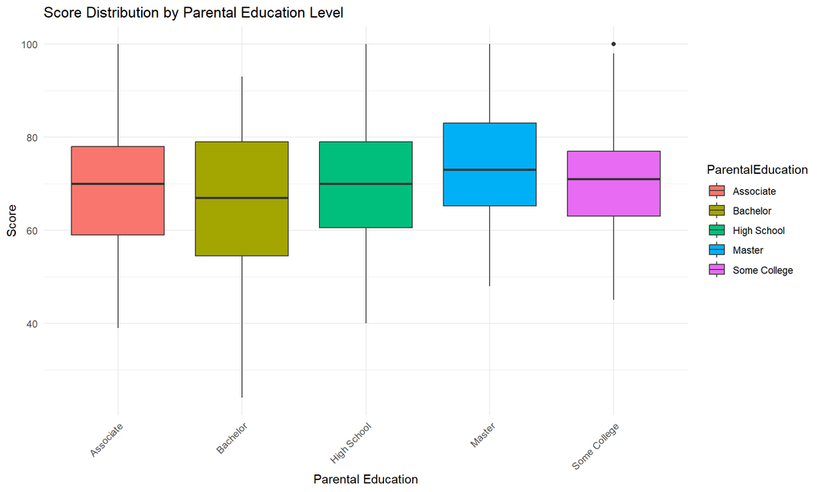

```r
scores_long <- student_data %>%
  select(ParentalEducation, MathScore, ReadingScore, WritingScore) %>%
  pivot_longer(cols = c(MathScore, ReadingScore, WritingScore),
               names_to = "Subject",
               values_to = "Score")

ggplot(scores_long, aes(x = ParentalEducation, y = Score, fill = ParentalEducation)) +
  geom_boxplot() +
  labs(title = "Score Distribution by Parental Education Level",
       x = "Parental Education",
       y = "Score") +
  theme_minimal() +
  theme(axis.text.x = element_text(angle = 45, hjust = 1))
```

### 5. Score Trends by Age

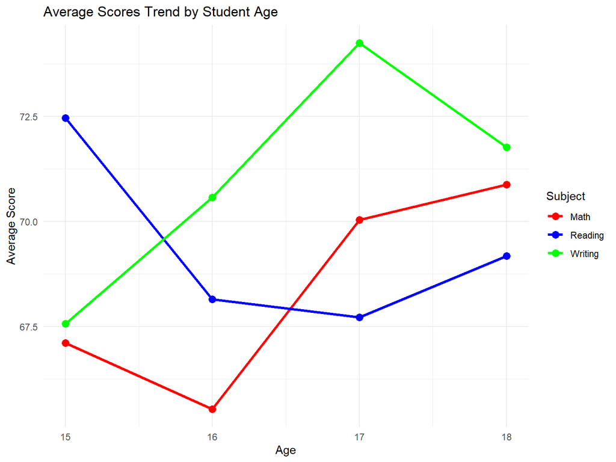

```r
age_trends <- student_data %>%
  group_by(Age) %>%
  summarise(
    Avg_Math = mean(MathScore),
    Avg_Reading = mean(ReadingScore),
    Avg_Writing = mean(WritingScore)
  ) %>%
  pivot_longer(cols = c(Avg_Math, Avg_Reading, Avg_Writing),
               names_to = "Subject",
               values_to = "Average_Score")

ggplot(age_trends, aes(x = Age, y = Average_Score, color = Subject, group = Subject)) +
  geom_line(size = 1.2) +
  geom_point(size = 3) +
  labs(title = "Average Scores Trend by Student Age",
       x = "Age",
       y = "Average Score") +
  theme_minimal() +
  scale_color_manual(values = c("Avg_Math" = "red",
                                 "Avg_Reading" = "blue",
                                 "Avg_Writing" = "green"),
                     labels = c("Math", "Reading", "Writing"))
```

**Interpretation:** The line chart shows how average scores vary across different age groups, revealing patterns in academic performance as students mature.

## Conclusion

This analysis reveals multiple factors influencing student performance including study habits, parental education background, and demographics. Schools and educators can use these insights to develop targeted interventions for improving student outcomes.